# mensik_ps12

2026-01-05

# 1

## 1a.

## 1b.

After California’s cigarette tax was implemented in 1989, the difference between California’s per-capita cigarette consumption and other states’ decreased by 27.35 percentage points, holding all else equal.

## 1c.

```
##             2.5 %    97.5 %
## treated -33.02223 -21.67599
```

```
## # A tibble: 1 × 7
##   term    estimate std.error statistic  p.value conf.low conf.high
##   <chr>      <dbl>     <dbl>     <dbl>    <dbl>    <dbl>     <dbl>
## 1 treated    -27.3      2.80     -9.76 6.69e-12    -33.0     -21.7
```

## 1d.

Show you get the same estimate for treated.

$Y_{it} = \alpha_i + \lambda_t + \beta(treated_{it}) + \epsilon_{it}$

treated still = -27.349

```r
year_f <- as.factor(california_prop99$Year)

m_lm <- lm(PacksPerCapita ~ State + year_f + treated, data = california_prop99 )

summary(m_lm)
```

```
##
## Call:
## lm(formula = PacksPerCapita ~ State + year_f + treated, data = california_prop99)
##
## Residuals:
##     Min      1Q  Median      3Q     Max
## -53.375  -5.797  -0.197   5.667  73.267
##
## Coefficients:
##                     Estimate Std. Error t value Pr(>|t|)
## (Intercept)         110.4685     2.8203  39.169  < 2e-16 ***
## StateArkansas         7.1000     2.9982   2.368 0.018048 *
## StateCalifornia      -4.3003     3.4501  -1.246 0.212853
## StateColorado        -0.1581     2.9982  -0.053 0.957965
## StateConnecticut     -8.6871     2.9982  -2.897 0.003835 **
## StateDelaware        32.2677     2.9982  10.762  < 2e-16 ***
## StateGeorgia          8.0645     2.9982   2.690 0.007255 **
## StateIdaho           -9.5677     2.9982  -3.191 0.001456 **
## StateIllinois         1.8581     2.9982   0.620 0.535566
## StateIndiana         31.7194     2.9982  10.579  < 2e-16 ***
## StateIowa            -2.5871     2.9982  -0.863 0.388388
## StateKansas          -1.8226     2.9982  -0.608 0.543385
## StateKentucky        78.4645     2.9982  26.170  < 2e-16 ***
## StateLouisiana       11.1742     2.9982   3.727 0.000203 ***
## StateMaine           13.9516     2.9982   4.653 3.65e-06 ***
## StateMinnesota       -8.5903     2.9982  -2.865 0.004245 **
## StateMississippi      2.6452     2.9982   0.882 0.377833
## StateMissouri        19.2516     2.9982   6.421 1.98e-10 ***
## StateMontana         -5.8645     2.9982  -1.956 0.050710 .
## StateNebraska        -8.0355     2.9982  -2.680 0.007467 **
## StateNevada          40.5548     2.9982  13.526  < 2e-16 ***
## StateNew Hampshire  103.5903     2.9982  34.550  < 2e-16 ***
## StateNew Mexico     -25.2161     2.9982  -8.410  < 2e-16 ***
## StateNorth Carolina  54.8129     2.9982  18.282  < 2e-16 ***
## StateNorth Dakota   -10.7161     2.9982  -3.574 0.000366 ***
## StateOhio            10.6065     2.9982   3.538 0.000420 ***
## StateOklahoma         9.0419     2.9982   3.016 0.002620 **
## StatePennsylvania    -1.1903     2.9982  -0.397 0.691436
## StateRhode Island    13.3129     2.9982   4.440 9.86e-06 ***
## StateSouth Carolina  13.8839     2.9982   4.631 4.06e-06 ***
```

[output cut: 31 more lines]

```
## year_f1993          -17.7705     2.6755  -6.642 4.78e-11 ***
## year_f1994          -18.4552     2.6755  -6.898 8.74e-12 ***
## year_f1995          -17.4987     2.6755  -6.540 9.25e-11 ***
## year_f1996          -19.4705     2.6755  -7.277 6.32e-13 ***
## year_f1997          -18.8987     2.6755  -7.064 2.82e-12 ***
## year_f1998          -19.7475     2.6755  -7.381 3.03e-13 ***
## year_f1999          -23.1552     2.6755  -8.655  < 2e-16 ***
## year_f2000          -28.6193     2.6755 -10.697  < 2e-16 ***
## treated             -27.3491     4.4095  -6.202 7.77e-10 ***
## ---
## Signif. codes:  0 '***' 0.001 '**' 0.01 '*' 0.05 '.' 0.1 ' ' 1
##
## Residual standard error: 11.8 on 1139 degrees of freedom
## Multiple R-squared:  0.8776, Adjusted R-squared:  0.8702
## F-statistic: 118.4 on 69 and 1139 DF,  p-value: < 2.2e-16
```

```r
#coeftest(m_lm, vcovCL(m_lm, cluster =~State))
```

## Problem 2

### 2a.

### 2b.

### 2c.

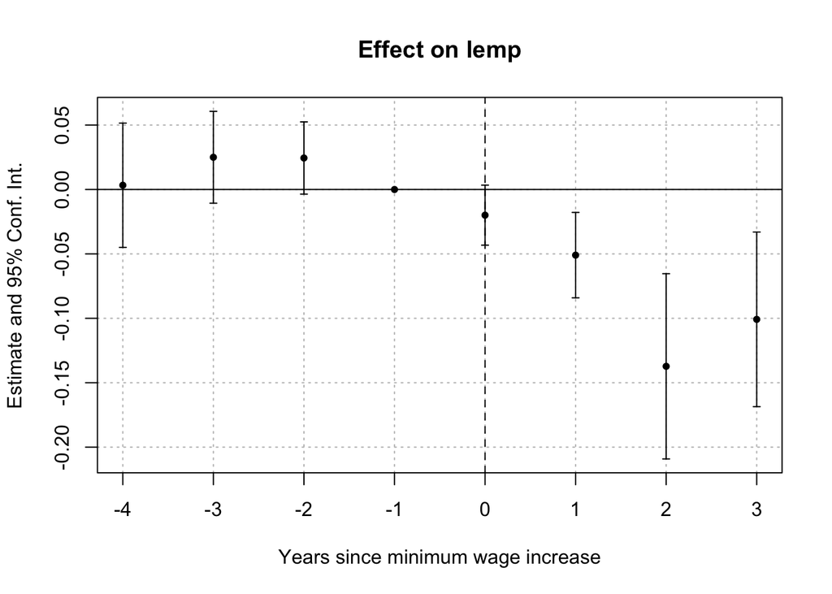

Also, while parallel trends might be violated, it seems worth noting that we don’t see an expected treatment effect going into effect, pre-treatment – instead, that treated counties, pre-treatment, had higher employment relative to untreated controls (k = -1 baseline).

### 2d.

Specifically, if places that have the best chance at increasing minimum wage have lowest unemployment (seems right), that might explain unparallel trends. Then, it makes sense that in the initial period after minimum wage increases go into effect, businesses might layoff part time etc youth workers, but later employment might rebound. This would help explain the large CI’s/less precise estimates at 2 and 3 years after implementation.

Overall though, the pre-treatment anti-parallel trends evidence coupled with the wave-like pattern suggests that evaluating the effect of min wage on youth unemployment probably requires a longer time horizon than the 7 years shown here.